# global-youtube-statistics-analysis

```python
import pandas as pd
import numpy as np
import seaborn as sns
import matplotlib.pyplot as plt
import pypopulation
from babel import Locale

%matplotlib inline
```

## Context

The dataset stores detailed information from the top 1000 Youtube channels based on the quantity of subscribers. Along with the name, ranking and subscribers, there are other columns related to the quantity of views, category, country and minimum and maximum level of earnings, among other useful features for analysis. As you can see, we can approach this dataset in a lot of different ways!

For this occasion, we will analyze in a general way the distribution of subscribers and views on these features and try to find relations in the data. We would also want to find answers on what to do to engage with people and therefore, get more views and subscribers to our channel.

## Data

```python
df = pd.read_csv('Global YouTube Statistics.csv', encoding = 'latin-1')
```

- At first glance, we can see that the channels with the most subscribers fall at least under 5 categories:
  - Channels related to content made in India. Movies, music, videoclips. T-Series, SET India, Zee Music Company are present in this category.
  - Official Youtube channels based on various type of content, like Music, Movies, Gaming, etc.
  - Channels related to children's content, like cartoons, sketches, unboxing of gifts, etc.
  - Channels related to bands or music artists.
  - Other individual Youtube channels.
- While it would be interesting and more meaningful to caracterize individual channels (not famous people, nor channels related to a band) to know the impact that they have, the data lacks a feature that would allow us to filter these cases.

```python
df.head(10)[['Youtuber', 'subscribers', 'video views','video_views_for_the_last_30_days', 'uploads', 'category', 'Country', 'channel_type', 'country_rank']]
```

|  | Youtuber | subscribers | video views | video_views_for_the_last_30_days | uploads | category | Country | channel_type | country_rank |
| --- | --- | --- | --- | --- | --- | --- | --- | --- | --- |
| 0 | T-Series | 245000000 | 2.280000e+11 | 2.258000e+09 | 20082 | Music | India | Music | 1.0 |
| 1 | YouTube Movies | 170000000 | 0.000000e+00 | 1.200000e+01 | 1 | Film & Animation | United States | Games | 7670.0 |
| 2 | MrBeast | 166000000 | 2.836884e+10 | 1.348000e+09 | 741 | Entertainment | United States | Entertainment | 1.0 |
| 3 | Cocomelon - Nursery Rhymes | 162000000 | 1.640000e+11 | 1.975000e+09 | 966 | Education | United States | Education | 2.0 |
| 4 | SET India | 159000000 | 1.480000e+11 | 1.824000e+09 | 116536 | Shows | India | Entertainment | 2.0 |
| 5 | Music | 119000000 | 0.000000e+00 | NaN | 0 | NaN | NaN | Music | NaN |
| 6 | ýýý Kids Diana Show | 112000000 | 9.324704e+10 | 7.316740e+08 | 1111 | People & Blogs | United States | Entertainment | 3.0 |
| 7 | PewDiePie | 111000000 | 2.905804e+10 | 3.918400e+07 | 4716 | Gaming | Japan | Entertainment | 1.0 |
| 8 | Like Nastya | 106000000 | 9.047906e+10 | 4.894700e+07 | 493 | People & Blogs | Russia | People | 5.0 |
| 9 | Vlad and Niki | 98900000 | 7.718017e+10 | 5.805740e+08 | 574 | Entertainment | United States | Entertainment | 5.0 |

## Analysis

### Countries

```python
subs_per_country = df.groupby(['Country'])['subscribers'].sum().reset_index().sort_values(['subscribers'], ascending = False)
subs_per_country['subs_rel'] = subs_per_country['subscribers']/subs_per_country['subscribers'].sum()
subs_per_country['subs_rel_cumsum'] = subs_per_country['subs_rel'].cumsum()
```

- We can see that there is a subscriber concentration on channels originated in the US, which represent more than 1/3 of the total number of subscribers from the data. Adding India, they represent almost 60%. The top 3 countries of this list also have a great demographic density, which could justify the quantity of subscribers (not counting subs from other countries).

```python
subs_per_country.head()
```

|  | Country | subscribers | subs_rel | subs_rel_cumsum |
| --- | --- | --- | --- | --- |
| 46 | United States | 7329500000 | 0.367480 | 0.367480 |
| 18 | India | 4310600000 | 0.216121 | 0.583601 |
| 6 | Brazil | 1221800000 | 0.061258 | 0.644859 |
| 45 | United Kingdom | 917400000 | 0.045996 | 0.690854 |
| 27 | Mexico | 626900000 | 0.031431 | 0.722285 |

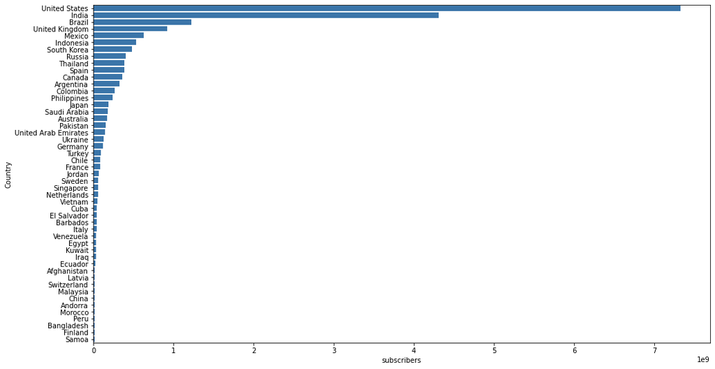

```python
plt.figure(figsize = (16,9))

sns.barplot(data = df.groupby(['Country'])['subscribers'].sum().reset_index().sort_values(['subscribers'], ascending = False)
            , x = 'subscribers', y = 'Country', estimator = sum, ci = False, color = sns.xkcd_rgb['bluish'], orient = 'h')

plt.show()
```

- Total views per country have a similar behavior to the number of subscribers, particularly for the top 4 countries as we saw in the previous graph.

```python
df.groupby(['Country'])['video views'].sum().reset_index().sort_values(['video views'], ascending = False).head()
```

|  | Country | video views |
| --- | --- | --- |
| 46 | United States | 3.690292e+12 |
| 18 | India | 2.281048e+12 |
| 6 | Brazil | 4.812090e+11 |
| 45 | United Kingdom | 4.305665e+11 |
| 41 | Thailand | 2.643180e+11 |

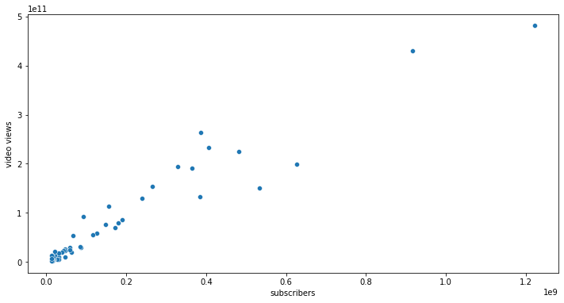

```python
plt.figure(figsize = (12,6))

sns.scatterplot(data = df.groupby(['Country'])[['subscribers', 'video views']].sum().sort_values(['subscribers'],ascending = False)[2:],
                x = 'subscribers', y = 'video views')

plt.show()
```

```python
df.groupby(['Country'])[['subscribers', 'video_views_for_the_last_30_days']].sum().corr()
```

|  | subscribers | video_views_for_the_last_30_days |
| --- | --- | --- |
| subscribers | 1.000000 | 0.988032 |
| video_views_for_the_last_30_days | 0.988032 | 1.000000 |

- We could create a new feature called **loyalty**, which consists in the mean proportion of subscribers that watch the videos when uploaded. We can calculate this column by dividing the total views by the quantity of uploaded videos (which is the mean views per video uploaded), and then dividing this value by the number of subscribers. This is an approximation, because it does not consider multiple views by one user on the same video and neither the distribution of the views (non subscriber/subscriber). Nonetheless, it is useful to measure the reach that the videos have.

```python
df['loyalty'] = ((df['video views']/df['uploads'])/df['subscribers'])
country_metrics = df[df['uploads'] != 1].groupby(['Country'])['loyalty'].mean().reset_index()
#country_metrics['loyalty'] = (country_metrics['video views']/country_metrics['uploads'])/country_metrics['subscribers']
country_metrics.loc[np.isinf(country_metrics['loyalty']), 'loyalty'] = 0
```

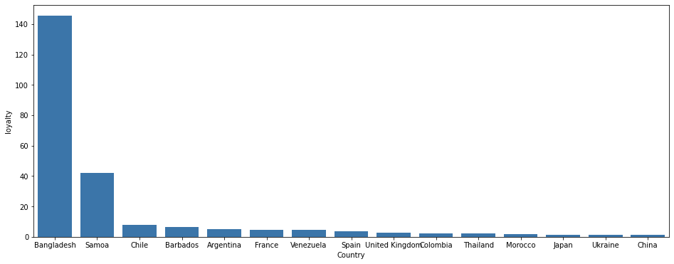

```python
plt.figure(figsize = (16,6))

sns.barplot(data = country_metrics.sort_values('loyalty', ascending = False)[:15], x = 'Country', y = 'loyalty', color = sns.xkcd_rgb['bluish'])

plt.show()
```

- Filtering the top 5 countries, we can see that France, Venezuela and Spain along with some other countries have a loyalty value greater than 1. This indicates that on average, each video is viewed by more people than the total number of subscribers. This could be related to a level of external popularity, meaning that a proportion of people that are not subscribers are watching the videos.
- On the other hand, countries like Indonesia and South Korea have a loyalty value of less than 1. Here we could deduce that the subscribers not always, on average, watch the videos of these channels when uploaded (which is kind of what you could expect of a normal Youtube channel).

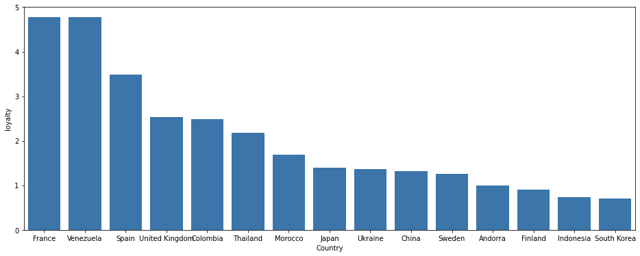

```python
plt.figure(figsize = (16,6))

sns.barplot(data = country_metrics.sort_values('loyalty', ascending = False)[5:20], x = 'Country', y = 'loyalty', color = sns.xkcd_rgb['bluish'])

plt.show()
```

- To get a sense of the size of subscribers of each channel, we could make a contrast with the values of the total population of each channel's origin country. We can get this data easily with the pypopulation package.
- At the same time, we would be interested in the language of the content of each channel. This could be useful mainly to understand if there are any preferences when deciding what channel to watch/subscribe. We can get this data through the Babel package, which gives us the most common language of each country. There could be some exceptions to some channels where the origin country does not match the language of the content, but it is a pretty good approximation.

```python
countries_population = {}
countries_languages = {}

for ab in df['Abbreviation'].unique():
    if ab is np.nan:
        continue

    population = pypopulation.get_population(ab)
    country_identifier = 'und_'+ab
    country_language = Locale.parse(country_identifier).language

    countries_languages[ab] = country_language
    if population is None:
        print('None')
    else:
        countries_population[ab] = population

df['country population'] = df['Abbreviation'].replace(countries_population)
df['country language'] = df['Abbreviation'].replace(countries_languages)
```

- We can see that the mean subscriber/population proportion of the top 10 countries has a high value, not necessarily because the channels from these countries have a large number of subscribers, but because of the size of each of these countries. Andorra, for example, has around 80 thousand inhabitants and the only channel that appears on this list that is originated in Andorra has around 15 million subscribers.
- Also, we see that Switzerland has a proportion of 226%, which indicates that a considerable number of subscribers are from other countries. In this sense, the only Swiss channel that appears in this list is the FIFA official channel, and considering that the category of this channel relates to sports, particularly football, it is very likely that people from around the world would be subscribed to this channel.
- On the other end, we find the US: the subscribers of these channels, on average, represent 7% of the total population of the country. However, the max value is almost 50% for some channels, like MrBeast. Considering the content that this channel uploads and the age range that approximately consumes this content (10 to 35 years, being aprox the 17.5% ot the US population), we could say that a strong international influence exists.

```python
df['country proportion'] = df['subscribers']/df['country population']
```

```python
df[df['video views'] > 0].groupby(['Country'])['country proportion'].describe().sort_values('mean', ascending = False).head(10)
```

| Country | count | mean | std | min | 25% | 50% | 75% | max |
| --- | --- | --- | --- | --- | --- | --- | --- | --- |
| Andorra | 1.0 | 195.742916 | NaN | 195.742916 | 195.742916 | 195.742916 | 195.742916 | 195.742916 |
| Barbados | 1.0 | 145.980315 | NaN | 145.980315 | 145.980315 | 145.980315 | 145.980315 | 145.980315 |
| Samoa | 1.0 | 66.464736 | NaN | 66.464736 | 66.464736 | 66.464736 | 66.464736 | 66.464736 |
| Latvia | 1.0 | 10.560496 | NaN | 10.560496 | 10.560496 | 10.560496 | 10.560496 | 10.560496 |
| Kuwait | 1.0 | 7.249679 | NaN | 7.249679 | 7.249679 | 7.249679 | 7.249679 | 7.249679 |
| El Salvador | 1.0 | 7.143352 | NaN | 7.143352 | 7.143352 | 7.143352 | 7.143352 | 7.143352 |
| Cuba | 1.0 | 4.085240 | NaN | 4.085240 | 4.085240 | 4.085240 | 4.085240 | 4.085240 |
| Singapore | 3.0 | 3.489043 | 1.20033 | 2.752662 | 2.796495 | 2.840327 | 3.857234 | 4.874141 |
| Finland | 1.0 | 2.391168 | NaN | 2.391168 | 2.391168 | 2.391168 | 2.391168 | 2.391168 |
| Switzerland | 1.0 | 2.262435 | NaN | 2.262435 | 2.262435 | 2.262435 | 2.262435 | 2.262435 |

```python
df[df['video views'] > 0].groupby(['Country'])['country proportion'].describe().sort_values('mean', ascending = False).tail(10)
```

| Country | count | mean | std | min | 25% | 50% | 75% | max |
| --- | --- | --- | --- | --- | --- | --- | --- | --- |
| Vietnam | 3.0 | 0.165177 | 0.021901 | 0.142025 | 0.154983 | 0.167942 | 0.176753 | 0.185565 |
| Egypt | 2.0 | 0.152409 | 0.002817 | 0.150416 | 0.151412 | 0.152409 | 0.153405 | 0.154401 |
| Mexico | 33.0 | 0.148908 | 0.057620 | 0.097197 | 0.109739 | 0.126200 | 0.171663 | 0.323730 |
| Pakistan | 6.0 | 0.119594 | 0.069941 | 0.057719 | 0.060952 | 0.097199 | 0.182278 | 0.205942 |
| Brazil | 62.0 | 0.093374 | 0.048894 | 0.058280 | 0.064914 | 0.073679 | 0.098081 | 0.315092 |
| Bangladesh | 1.0 | 0.085252 | NaN | 0.085252 | 0.085252 | 0.085252 | 0.085252 | 0.085252 |
| Indonesia | 28.0 | 0.070485 | 0.022375 | 0.045820 | 0.055335 | 0.064295 | 0.076582 | 0.125635 |
| United States | 311.0 | 0.069400 | 0.050871 | 0.037777 | 0.044784 | 0.055752 | 0.073422 | 0.505728 |
| India | 168.0 | 0.018778 | 0.018199 | 0.009002 | 0.010392 | 0.012551 | 0.020729 | 0.179301 |
| China | 1.0 | 0.012592 | NaN | 0.012592 | 0.012592 | 0.012592 | 0.012592 | 0.012592 |

- The average shows that in each channel, on average, 70% of the population is subscribed. This, besides being excessive, shows us that there are significant outliers and data that deviate greatly from one another. This is understandable considering the errors seen in the data and also the size of the population in different countries.

```python
df['country proportion'].mean(),df['country proportion'].std()
```

```
(0.7081193375379334, 8.56856388800255)
```

- If we analyze the number of views by language, we can see that English is predominant throughout the platform. Being one of the most spoken languages in the world, English accounts for 45% of all the views of the top 1000 channels with the highest number of subscribers.
- This is important because considering that India is one of the most populated countries in the world, it represents only 23% of the visits, which probably only come from users of this country because of the language spoken.
- In addition to this, they are followed by Spanish with 7.7% (with an important percentage considering that it is a language spoken in Spain and several countries in Central and South America), Portuguese with almost 5% (in Portugal and Brazil, the latter with a high density of people in its territory) and Thai with 2.7%.

```python
views_per_language = df.groupby(['country language'])['video views'].sum().sort_values(ascending = False).reset_index()
views_per_language['percentage'] = views_per_language['video views']/views_per_language['video views'].sum()
```

```python
views_per_language.head()
```

|  | country language | video views | percentage |
| --- | --- | --- | --- |
| 0 | en | 4.439415e+12 | 0.453039 |
| 1 | hi | 2.281048e+12 | 0.232779 |
| 2 | es | 7.587573e+11 | 0.077431 |
| 3 | pt | 4.812090e+11 | 0.049107 |
| 4 | th | 2.643180e+11 | 0.026973 |

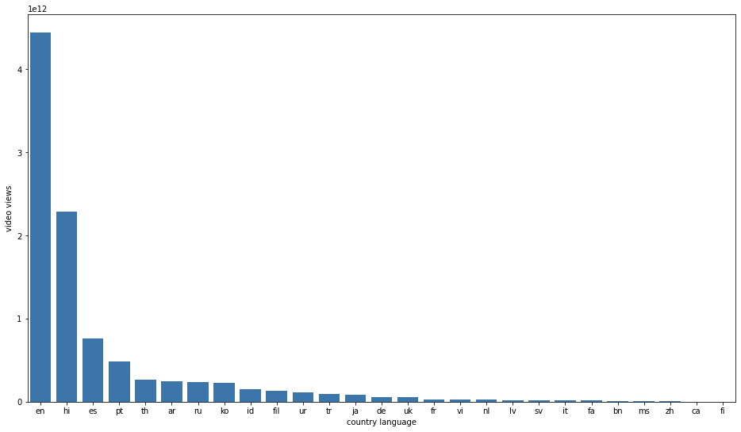

```python
plt.figure(figsize = (16,9))

sns.barplot(data = df.groupby(['country language'])['video views'].sum().sort_values(ascending = False).reset_index(),
            x = 'country language', y = 'video views',
            ci = False, color = sns.xkcd_rgb['bluish'])

plt.show()
```

### Categories

- Of these channels, the most views are related to the music category. It makes sense considering that T Series is the channel with the most subscribers in the world and also because of the nature of this category: the repetition of views when people return to the same video to listen or watch the video clip.
- It is followed by Entertainment, People & Blogs and Gaming, being the categories that one can find most frequently on the platform. Education remains top 5 in the categories, in the form of channels providing mainly children's content; songs and unboxing of gifts.
- The **channel type** variable follows a similar distribution to **category**. If we replace views by subscribers we can see similar patterns for each of the categories.

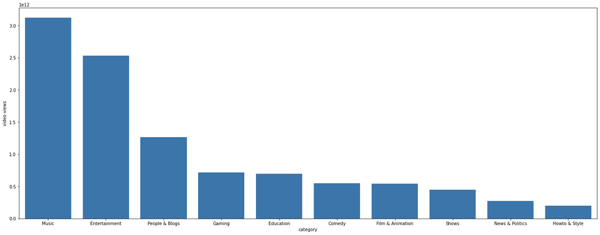

```python
plt.figure(figsize = (24,9))

sns.barplot(data = df.groupby(['category'])['video views'].sum().sort_values(ascending = False).reset_index()[:10],
            x = 'category', y = 'video views', estimator = sum, ci = False, color = sns.xkcd_rgb['bluish'])

plt.show()
```

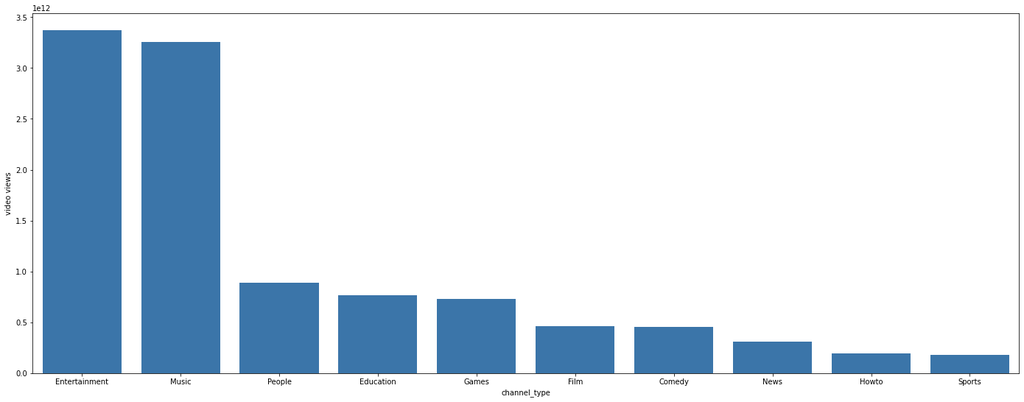

```python
plt.figure(figsize = (24,9))

sns.barplot(data = df.groupby(['channel_type'])['video views'].sum().sort_values(ascending = False).reset_index()[:10],
            x = 'channel_type', y = 'video views', estimator = sum, ci = False, color = sns.xkcd_rgb['bluish'])

plt.show()
```

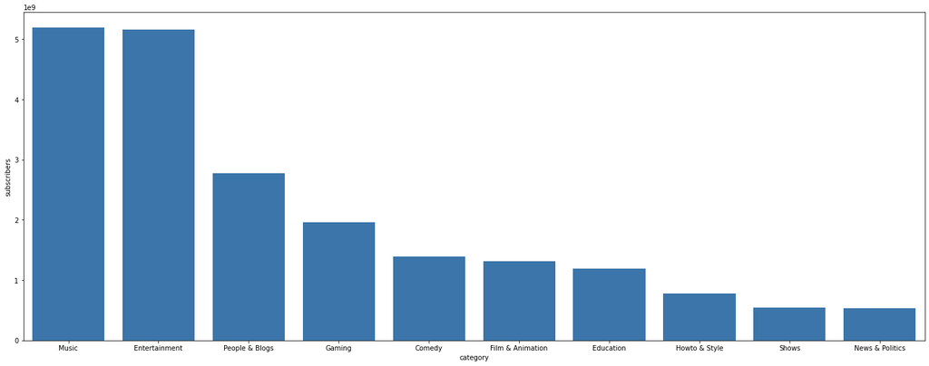

```python
plt.figure(figsize = (24,9))

sns.barplot(data = df.groupby(['category'])['subscribers'].sum().sort_values(ascending = False).reset_index()[:10],
            x = 'category', y = 'subscribers', estimator = sum, ci = False, color = sns.xkcd_rgb['bluish'])

plt.show()
```

- Taking the top 6 countries with the highest number of subscribers and analyzing their subscriber distribution by category, we can find that Music channels are preferred in almost all these countries, followed almost always by Entertainment.
- For example, in the UK the Gaming category holds the third place while in the US it is People & Blogs. These differences are also noticeable in other countries.

```python
cat_per_country = df[(df['video views'] != 0) & (df['Country'].isin(['United States', 'India', 'Brazil', 'United Kingdom', 'Mexico', 'Indonesia']))].groupby(['Country', 'category'])['subscribers'].sum().reset_index()
```

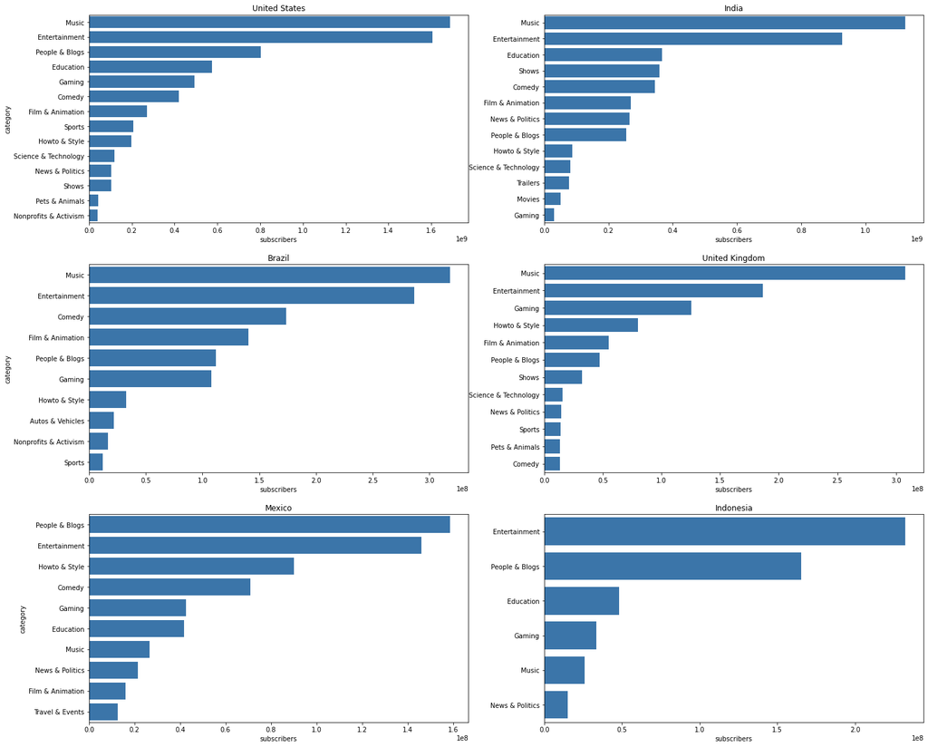

```python
fig, axes = plt.subplots(3, 2, figsize = (23,20))

cont = 0
pair = 0
paises = ['United States', 'India', 'Brazil', 'United Kingdom', 'Mexico', 'Indonesia']

for i in range(3):
    for j in range(2):

        sns.barplot(data = cat_per_country[cat_per_country['Country'] == paises[cont]].sort_values('subscribers', ascending = False),
                    y = 'category', x = 'subscribers', ax = axes[i,j], orient = 'h', color = sns.xkcd_rgb['bluish'])
        axes[i,j].set_title(paises[cont])
        cont+=1

        if pair == 0:
            pair = 1
        else:
            axes[i,j].set_ylabel(None)
            pair = 0

plt.show()
```

- In terms of the number of videos, the largest number is located in News & Politics, most of which are made up of official channels of international news and information. However, being the category with the highest number of videos uploaded, it is one of the categories with the lowest total views, according to the above chart.
- In this sense, the other categories do not necessarily have to upload many videos, but they have a greater reach to the public, attract more attention, and therefore have more views.

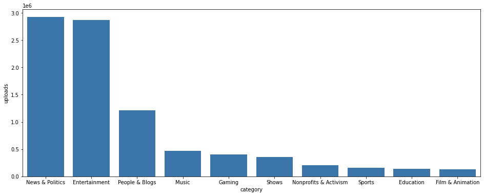

```python
plt.figure(figsize = (16,6))

sns.barplot(data = df.groupby(['category'])['uploads'].sum().sort_values(ascending = False).reset_index()[:10],
           x = 'category', y = 'uploads', color = sns.xkcd_rgb['bluish'])

plt.show()
```

### Earnings

- First of all we calculate a column of average monthly earnings (simply called **mean earnings**), to have an approximate value and not an interval. This will allow us to contrast the monthly earnings with other variables. In addition, to know more recently how much money each view generates, we divide these earnings by the views of the last 30 days.
- In order to eliminate from the analysis the official Youtube channels and other channels that do not necessarily generate earnings, a filter is made (the official Youtube channels such as Music or Gaming do not have earnings or views). In this way, it can be seen that the earnings per view do not differ by category and remain practically identical among them, with an average of 2.1 USD per 1000 views.

```python
df['mean earnings'] = (df['highest_monthly_earnings']+df['lowest_monthly_earnings'])/2
df['mean earnings per view'] = df['mean earnings']/df['video_views_for_the_last_30_days']
```

```python
mask_not_channels = (df['video views'] > 0) & (df['lowest_monthly_earnings'] != 0)
(df[mask_not_channels].groupby(['category'])['mean earnings per view'].mean()*1000)
```

```
category
Autos & Vehicles         2.115778
Comedy                   2.122732
Education                2.129824
Entertainment            2.122752
Film & Animation         2.129438
Gaming                   2.126983
Howto & Style            2.121802
Movies                   2.124871
Music                    2.126984
News & Politics          2.126568
Nonprofits & Activism    2.125282
People & Blogs           2.125534
Pets & Animals           2.129160
Science & Technology     2.124804
Shows                    2.131341
Sports                   2.131303
Trailers                 2.124990
Travel & Events          2.125327
Name: mean earnings per view, dtype: float64
```

- However, the category with the highest earnings of the entire dataset is Entertainment, accumulating $79.7 million on average on a monthly basis (28% of the total), followed by Music (21%), People & Blogs (13.3%) and Comedy (8.5%).

```python
earnings_per_cat = df.groupby(['category'])['mean earnings'].sum().reset_index().sort_values('mean earnings', ascending = False)
earnings_per_cat['relative earnings'] = earnings_per_cat['mean earnings']/earnings_per_cat['mean earnings'].sum()
```

```python
earnings_per_cat
```

|  | category | mean earnings | relative earnings |
| --- | --- | --- | --- |
| 3 | Entertainment | 7.972474e+07 | 0.277089 |
| 8 | Music | 5.927609e+07 | 0.206018 |
| 11 | People & Blogs | 3.834726e+07 | 0.133279 |
| 1 | Comedy | 2.450120e+07 | 0.085156 |
| 4 | Film & Animation | 1.790520e+07 | 0.062231 |
| 2 | Education | 1.661735e+07 | 0.057755 |
| 14 | Shows | 1.407005e+07 | 0.048901 |
| 5 | Gaming | 1.357658e+07 | 0.047186 |
| 9 | News & Politics | 8.876720e+06 | 0.030852 |
| 15 | Sports | 4.713500e+06 | 0.016382 |
| 6 | Howto & Style | 4.097378e+06 | 0.014241 |
| 13 | Science & Technology | 1.824768e+06 | 0.006342 |
| 12 | Pets & Animals | 1.688816e+06 | 0.005870 |
| 0 | Autos & Vehicles | 1.154650e+06 | 0.004013 |
| 7 | Movies | 4.831000e+05 | 0.001679 |
| 10 | Nonprofits & Activism | 4.148000e+05 | 0.001442 |
| 16 | Trailers | 3.845000e+05 | 0.001336 |
| 17 | Travel & Events | 6.590000e+04 | 0.000229 |

- If we contrast the average revenue for the views of the last 30 days, we can see an interesting linear relationship between these two variables, practically following a straight line. If we calculate the correlation between these two variables, we can see that the coefficient is 0.68, which effectively confirms this relationship.

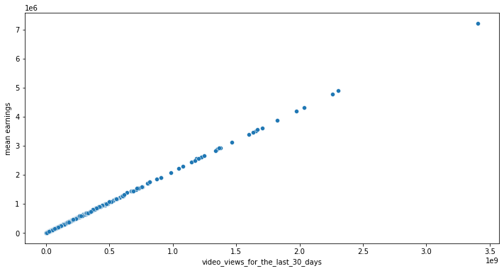

```python
plt.figure(figsize = (12,6))

sns.scatterplot(data = df[(df['mean earnings'] > 0)], x = 'video_views_for_the_last_30_days', y = 'mean earnings')

plt.show()
```

[figure not shown]

```python
plt.figure(figsize = (12,6))

sns.scatterplot(data = df[(df['mean earnings'] > 0)], x = 'video_views_for_the_last_30_days', y = 'mean earnings')

plt.show()
```

```python
df['video_views_for_the_last_30_days'].corr(df['mean earnings'])
```

```
0.6802930661216573
```

```python
df['video_views_for_the_last_30_days'].quantile(0.25),df['video_views_for_the_last_30_days'].quantile(0.50),df['video_views_for_the_last_30_days'].quantile(0.75)
```

```
(20137500.0, 64085000.0, 168826500.0)
```

```python
df.loc[df['video_views_for_the_last_30_days'] < df['video_views_for_the_last_30_days'].quantile(0.25), 'Quartile'] = 'Q1'
df.loc[(df['video_views_for_the_last_30_days'] >= df['video_views_for_the_last_30_days'].quantile(0.25)) & (df['video_views_for_the_last_30_days'] < df['video_views_for_the_last_30_days'].quantile(0.50)), 'Quartile'] = 'Q2'
df.loc[(df['video_views_for_the_last_30_days'] >= df['video_views_for_the_last_30_days'].quantile(0.50)) & (df['video_views_for_the_last_30_days'] < df['video_views_for_the_last_30_days'].quantile(0.75)), 'Quartile'] = 'Q3'
```

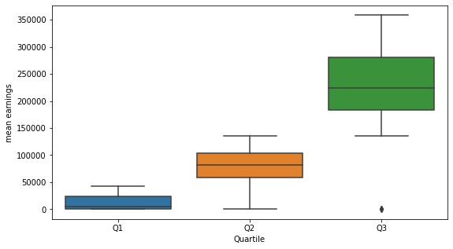

```python
plt.figure(figsize = (9,5))

sns.boxplot(data = df, x = 'Quartile', y = 'mean earnings', showfliers = True, order = ['Q1', 'Q2', 'Q3'])

plt.show()
```

## Conclusions

- Although the largest number of subscribers is concentrated in a couple of countries, it is not necessary to be originally from a particular country to have a greater impact of views/subscribers. What is important to consider is the **language of the content generated**. Almost half of the total views come from channels that produce content in English (or very likely, at least), and this is without counting the channels that upload content in English but are not from a country where English is an official language. Globally, it is the language with the most speakers (over 1.4 billion), so it is an important factor for any channel to reach more people.
- Although subscribers are a factor directly related to the number of views, not all of them will watch every video uploaded from a channel but a relatively variable percentage that probably depends on other variables not demonstrated in this analysis (frequency of uploads, monotony of content, youtube drama, etc). However, in order to grow and keep up with these Youtube giants it is also important to have a reach outside of this subscriber base, especially of new viewers interested in the content who understand the language, thus increasing both views and subscribers to the channel.
- Along the same lines as the previous point, there is strong evidence of international users in the most influential channels. Most likely, the content developed by these channels cuts across different categories or is highly appealing to a certain group of the world population (e.g. children's audience in the case of several channels in the dataset).
- A higher number of uploads does not necessarily mean more views, in fact it depends to a greater extent on the category. In this sense, the most influential channels belong to the Entertainment, Music, People & Blogs and Gaming categories.
- Views and average earnings have a strong linear relationship. The higher the views, the higher the earnings.
- Earnings per view do not vary by category, and on average are $2.1 per 1000 views, a little less than the $4 to $20 that Youtube pays for the same amount of views (based on approximations). What does affect earnings are the categories, and the ones that generate the most earnings are obviously also the ones that collect the most views (Entertainment, Music and People & Blogs).

## Comments

- Possibly there are data errors, in Afghanistan LinkinPark is shown without videos. Although it has a similar number of subscribers, the data is wrong both in the country and in the number of videos uploaded, which is greater than zero.

```python
df[df['Country'] == 'Afghanistan']
```

|  | rank | Youtuber | subscribers | video views | category | Title | uploads | Country | Abbreviation | channel_type | ... | Urban_population | Latitude | Longitude | loyalty | country population | country language | country proportion | mean earnings | mean earnings per view | Quartile |
| --- | --- | --- | --- | --- | --- | --- | --- | --- | --- | --- | --- | --- | --- | --- | --- | --- | --- | --- | --- | --- | --- |
| 377 | 378 | Linkin Park | 20400000 | 1.339700e+10 | Music | linkinpark | 0 | Afghanistan | AF | Games | ... | 9797273.0 | 33.93911 | 67.709953 | inf | 38041754.0 | fa | 0.536253 | 0.0 | NaN | NaN |

1 rows × 35 columns

- Here it shows Invictus (Spanish youtuber) as a channel originating from Chile and with 17 videos uploaded (which is nowhere near what it really is).

```python
df[df['Country'] == 'Chile'][['Youtuber', 'subscribers', 'video views', 'uploads']]
```

|  | Youtuber | subscribers | video views | uploads |
| --- | --- | --- | --- | --- |
| 44 | JuegaGerman | 48100000 | 1.463171e+10 | 2052 |
| 339 | invictor | 21500000 | 8.409642e+09 | 17 |
| 509 | DeGoBooM | 17600000 | 6.306205e+09 | 4702 |